# Introgression statistics

J. Ignacio Lucas Lledó

30/10/2020

# Introduction

In the first manuscript we suggested two conclusions that were not fully supported by the data: first, that current levels of hybridization are higher in the Russian contact zone between the Apennine lineage of *E. europaeus* and the Asian lineage of *E. roumanicus* than in the Central European zone between the same lineage of *E. europaeus* and the Balkan lineage of *E. roumanicus*. And segond, that the frequency of hybridization must have been higher in the past and then declined in Central Europe. One of the limitations of our previous analysis is that the *D* and *f* statistics of introgression were not systematically compared, and they lacked estimates of dispersion. In order to compensate these limitations, here I report the *D* and *f* statistics between all pairs of populations that could be assigned the **P2** and **P3** positions in the nested topology where *ABBA/BABA* statistics are usually computed, namely (((P1, P2), P3), O). *E. concolor* would always be **P1** (it would be redundant to switch it with **P2**, because that would only flip the sign of the *D* statistic). In the **P2** position, we could have either the Balkan or the Asian lineage of *E. roumanicus*. And in the **P3** position, we can consider the Iberian or the Apennine lineages of *E. europaeus* or *E. amurensis*. Lineages currently undergoing hybridization must have a higher fraction *f* of introgressed variation than lineages currently separated. The amount of introgressed variation among the latter can only be inherited from ancient episodes of hybridization, during previous interglacials.

Before, we excluded visibly admixed or hybrid individuals from the computation of *D* and *f* statistics, aiming at a measure of only ancient hybridization. But we need to include those individuals in the population that contribute the most to their genetic makeup in order to make the statistics representative of total introgression, both ancient and ongoing.

The problem of using recently admixed individuals in computing *D* and *f* statistics is that their chromosomes may contain large blocks of introgressed DNA, in linkage. If linked introgressed DNA spans long stretches of a chromosome, the block jackknife procedure to estimate the dispersion of the statistics can fail to remove the dependency among pseudo-samples. Unless using very large blocks, which is not feasible with an incompletely assembled reference genome, we could be underestimating dispersion with the block jackknife approach.

The *D* and *f* statistics are based on frequencies of site patterns. For the purposes of estimating them, variable sites along a genome are all equivalent, just as random draws of either derived or ancestral alleles from a binomial distribution. However, linkage can make the draws dependent, among closely linked SNPs that share coalescence history. Thus, any one individual in the sample is a collection of blocks of more or less independent origin. The dispersion in *D* and *f* statistics correspond to the random sampling of such linkage blocks, their size and number depending on how long ago introgression happened. As long as any member of a population can be considered a random collection of a sufficient number of such blocks, *D* and *f* statistics can be estimated with only one individual from each population. Adding individuals is just like adding those units of sampling that I call “linkage blocks”. Individuals are our probes into the ancestral recombination graph. As long as individuals are random members of the population, rather than relatives, we can assess the dispersion of *D* and *f* statistics not only by re-sampling blocks, but also by re-sampling individuals. In this way, we can be sure that pseudo-samples produced by removing one or more individuals at a time avoid the dependence induced by linkage within any such individual.

# Delete-*d* jackknife design

The starting point is an assignment of individuals to populations. I depart from the results of Admixture in `/data/kristyna/hedgehog/results_2020/2020-06-12/erinaceus_all_2020.6.Q`, where I manually checked that the six ancestralities coincide with the following populations, and in this order:

- 1. *E. roumanicus*, Asian lineage.
- 2. *E. europaeus*, Iberian lineage.
- 3. *E. concolor*.
- 4. *E. amurensis*.
- 5. *E. roumanicus*, Balkan lineage.
- 6. *E. europaeus*, Apennine lineage.

I assign every individual to the population that contributes the most to its genome. In the table below I show the number of individuals assigned to every population, the position of the population in the tree for the purpose of computing *D* and *f* statistics, the number *d* of individuals removed in each pseudo-replicate, and the number of pseudoreplicates obtained.

| Population | Size | Position | *d* | Num. replicates |
| --- | --- | --- | --- | --- |
| *E. concolor* | 5 | P1 | 1 | 5 |
| *E. roumanicus*, Balkan | 20 | P2 | 5 | 100 |
| *E. roumanicus*, Asian | 24 | P2 | 5 | 100 |
| *E. europaeus*, Iberian | 5 | P3 | 1 | 5 |
| *E. europaeus*, Apennine | 19 | P3 | 5 | 100 |
| *E. amurensis* | 2 | P3 | 1 | 2 |
| *Hemiechinus* | 1 | Outgroup | 0 | 1 |

There are six analysis, produced by the combinations of a P2 and a P3 population. What I did was to combine all pseudoreplicates from all populations. The maximum number of pseudoreplicates are those where either the Balkan or the Asian lineage of *E. roumanicus* is the P2 population and the Apennine lineage of *E. europaeus* is the P3 population. In those cases, we have $5\times 100\times 100=50000$ pseudoreplicates. The total number of individuals left out of the computation in each pseudoreplicate is the sum of *d* values in the table above among all populations involved in that analysis, and it is shown below in the *d* column. The column *n* indicates the original total number of individuals, among all 3 populations.

| P2 | P3 | *d* | *n* | Num. rep. |
| --- | --- | --- | --- | --- |
| *E. roumanicus*, Balkan | *E. europaeus*, Iberian | 7 | 30 | 2500 |
| *E. roumanicus*, Balkan | *E. europaeus*, Apennine | 11 | 44 | 50000 |
| *E. roumanicus*, Balkan | *E. amurensis* | 7 | 27 | 1000 |
| *E. roumanicus*, Asian | *E. europaeus*, Iberian | 7 | 34 | 2500 |
| *E. roumanicus*, Asian | *E. europaeus*, Apennine | 11 | 48 | 50000 |
| *E. roumanicus*, Asian | *E. amurensis* | 7 | 31 | 1000 |

The variance of an estimated statistic can be estimated by the delete-*d* jackknife approach, typically with this formula:

$V_{J(d)} = \frac{n-d}{dN}\sum\left( \hat{\theta}_S - \frac{1}{N} \sum \hat{\theta}_S \right)^2$

(Shi 1988) Where $N$ is supposed to be the number of subsamples of size $n-d$, assumed to be $n \choose d$. However, it is impractical to explore absolutely all possible combinations of $n-d$ elements out of $n$, and I limited the number of replicates to the figures shown in the table above. $\hat{\theta}_S$ is the statistic estimate obtained with the $S^{\mathrm{th}}$ subsample of size $n-d$.

There are a couple reasons why the formula is not applicable to the pseudoreplicates I generated. First, because the *D* and *f* statistics are not functions of a single sample, but of 3 samples from 3 different populations (leaving the outgroup out, because we only have one individual available). And second, because I will just substitute $N$ for the actual number of replicates used, rather than for $n \choose d$, and I don’t know if that is correct. In any case, it is the best I can do for the moment, and I hope it provides conservative estimates of dispersion.

```r
JackDelDVar <- function(X, n, d) {
  V <- ((n - d) / (d * sum(!is.na(X)))) * sum((X-mean(X, na.rm=TRUE))^2, na.rm=TRUE)
}

comparisons <- c('balkan_iberian','balkan_apennine','balkan_amurensis',
                 'asian_iberian','asian_apennine','asian_amurensis')
NumSamples <- c(30, 44, 27, 34, 48, 31)
names(NumSamples) <- comparisons
Deleted    <- c( 7, 11,  7,  7, 11,  7)
names(Deleted) <- comparisons
comparisons.list <- as.list(comparisons)
names(comparisons.list) <- comparisons
# passing a named list to plyr::ldply forces it to use row names. I tried before
# to make a data frame with sapply, but it outputs a list.
DandF <- ldply(comparisons.list,
               .fun = function(x) read.table(paste0(x, '/stats.tsv'),
                                             col.names=c('D','f_hom','f_d','f_dM')))
StdDev <- ldply(comparisons.list,
                .fun = function(x) {
                  reps <- read.table(paste0(x, '/jackknife.tsv'),
                                     col.names = c('D','f_hom','f_d','f_dM'))
                  data.frame(
                    D     = sqrt(JackDelDVar(reps$D,     NumSamples[x], Deleted[x])),
                    f_hom = sqrt(JackDelDVar(reps$f_hom, NumSamples[x], Deleted[x])),
                    f_d   = sqrt(JackDelDVar(reps$f_d,   NumSamples[x], Deleted[x])),
                    f_dM  = sqrt(JackDelDVar(reps$f_dM,  NumSamples[x], Deleted[x]))
                  )
                })
names(StdDev) <- paste("SD",names(StdDev),sep='.')
DandF
```

```
##                .id         D      f_hom        f_d       f_dM
## 1   balkan_iberian 0.2013647 0.05416648 0.03337319 0.03857319
## 2  balkan_apennine 0.3092624 0.08970560 0.05611992 0.06528880
## 3 balkan_amurensis 0.1323542 0.02397323 0.01675847 0.01756816
## 4    asian_iberian 0.3549594 0.10971207 0.06905715 0.08870201
## 5   asian_apennine 0.4711382 0.16320340 0.10465704 0.14621233
## 6  asian_amurensis 0.2437193 0.04860634 0.03446629 0.03848418
```

```r
StdDev
```

```
##             SD..id       SD.D   SD.f_hom      SD.f_d     SD.f_dM
## 1   balkan_iberian 0.06308304 0.01922410 0.012290701 0.015077253
## 2  balkan_apennine 0.07915585 0.03273325 0.019645482 0.023277175
## 3 balkan_amurensis 0.07125286 0.01384541 0.009764693 0.009949474
## 4    asian_iberian 0.07005049 0.02869209 0.019640050 0.024089210
## 5   asian_apennine 0.07041430 0.04517925 0.028379622 0.036015087
## 6  asian_amurensis 0.06347631 0.01610319 0.011669845 0.012135171
```

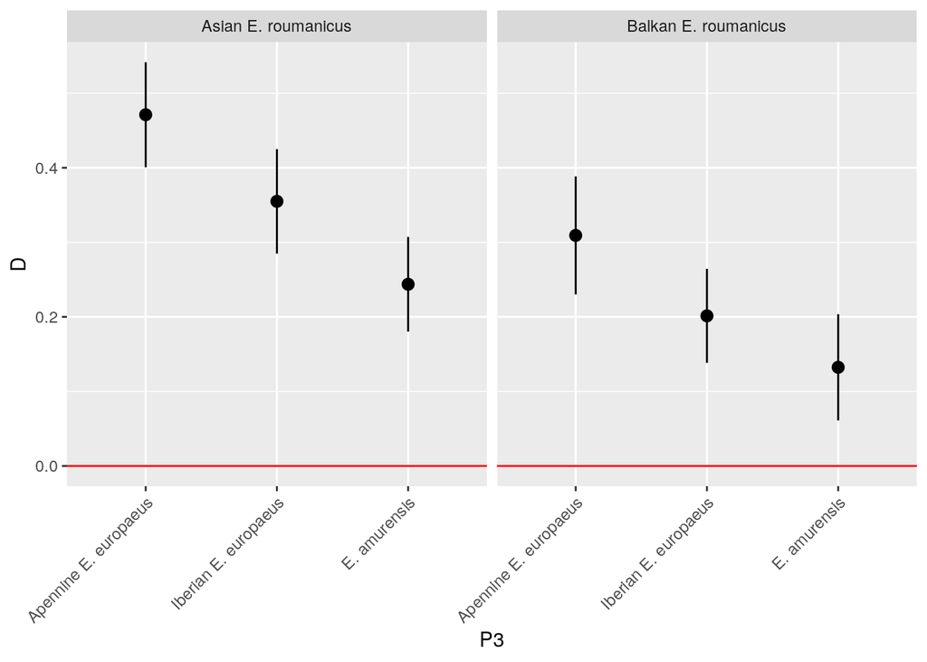

```r
DF.SD <- cbind(DandF, StdDev[,2:5])
DF.SD$P2 <- factor(rep(c('Balkan E. roumanicus', 'Asian E. roumanicus'), each=3))
DF.SD$P3 <- factor(rep(c('Iberian E. europaeus', 'Apennine E. europaeus', 'E. amurensis'), 2),
                   levels=c('Apennine E. europaeus', 'Iberian E. europaeus', 'E. amurensis'),
                   ordered=TRUE)
ggplot(DF.SD, mapping=aes(x=P3, y=D)) +
  geom_pointrange(mapping=aes(ymin=D-SD.D, ymax=D+SD.D)) + facet_wrap(~P2) +
  geom_hline(yintercept=0, color='red') + theme(axis.text.x=element_text(angle=45, hjust=1))
```

```r
ggsave('D.png')
```

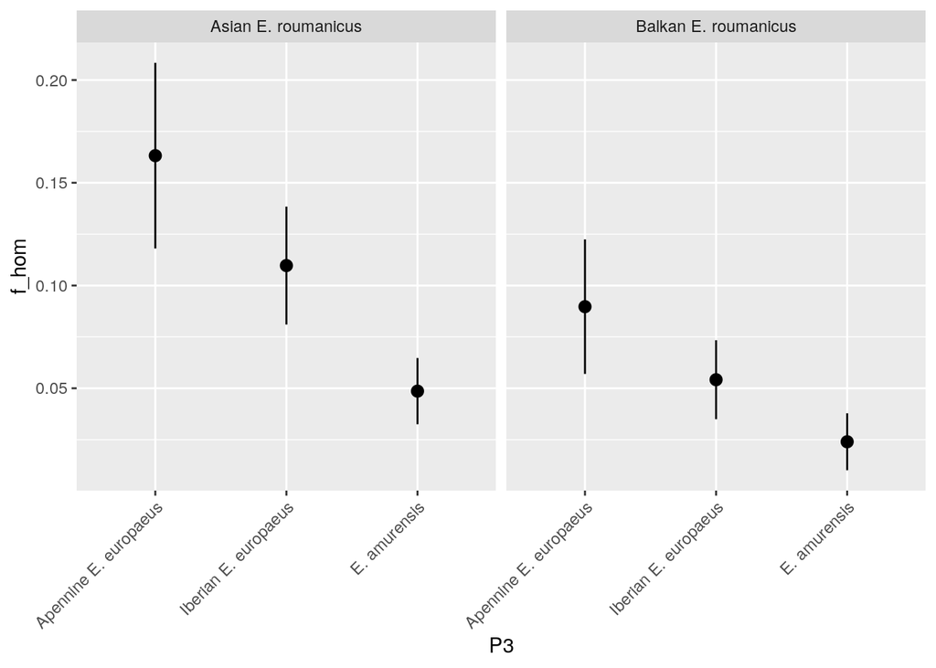

```r
ggplot(DF.SD, mapping=aes(x=P3, y=f_hom)) +
  geom_pointrange(mapping=aes(ymin=f_hom - SD.f_hom, ymax = f_hom + SD.f_hom)) +
  facet_wrap(~P2) + theme(axis.text.x=element_text(angle=45, hjust=1))
```

```r
ggsave('f_hom.png')
```

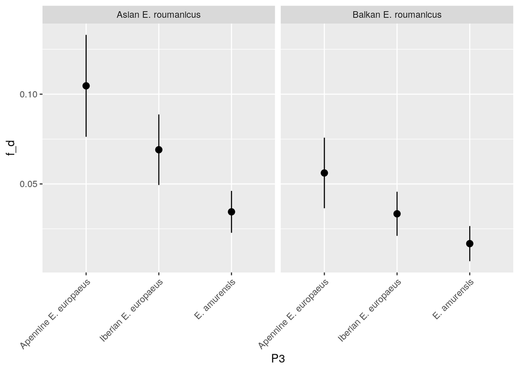

```r
ggplot(DF.SD, mapping=aes(x=P3, y=f_d)) +
  geom_pointrange(mapping=aes(ymin=f_d - SD.f_d, ymax = f_d + SD.f_d)) +
  facet_wrap(~P2) + theme(axis.text.x=element_text(angle=45, hjust=1))
```

```r
ggsave('f_d.png')
```

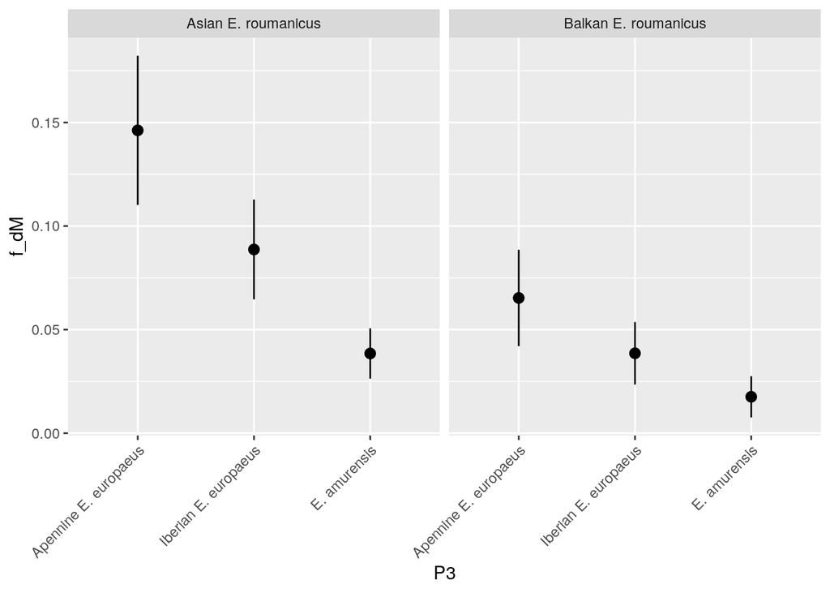

```r
ggplot(DF.SD, mapping=aes(x=P3, y=f_dM)) +
  geom_pointrange(mapping=aes(ymin=f_dM - SD.f_dM, ymax = f_dM + SD.f_dM)) +
  facet_wrap(~P2) + theme(axis.text.x=element_text(angle=45, hjust=1))
```

```r
ggsave('f_dM.png')
```

# References

Shi, X. 1988. “A Note on the Delete-*d* Jackknife Variance Estimators.” *Statistics & Probability Letters* 6: 341–47.